# Stock Market Valuation by Shawn P Emhe II

### Inflation

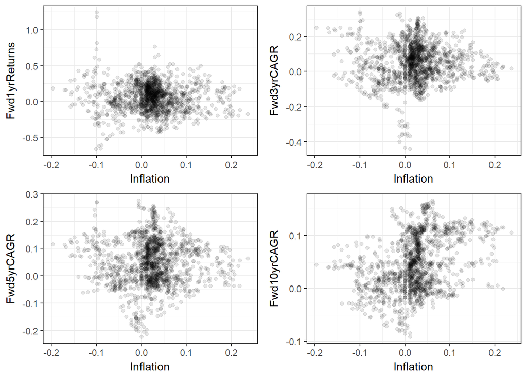

Although it is not readily apparent in the plot, the `cor.test` function found a weak correlation of .36 between CPIChange and Fwd10yrCAGR. It looks like inflation only correlates with returns over long periods.

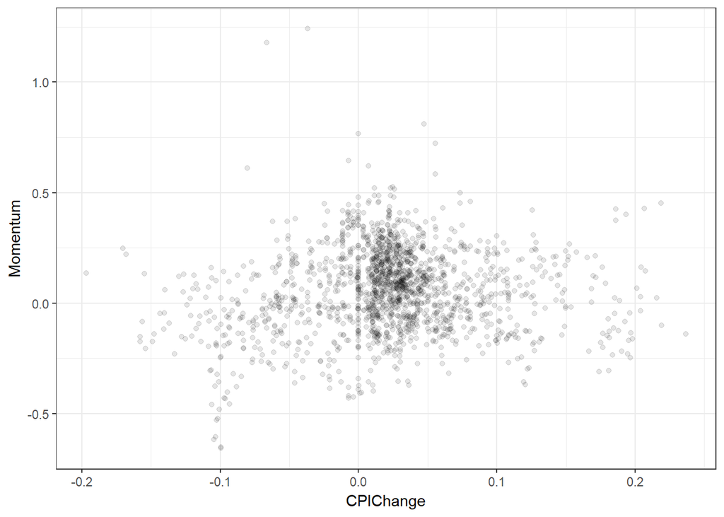

Inflation does not show correlation to Momentum either.

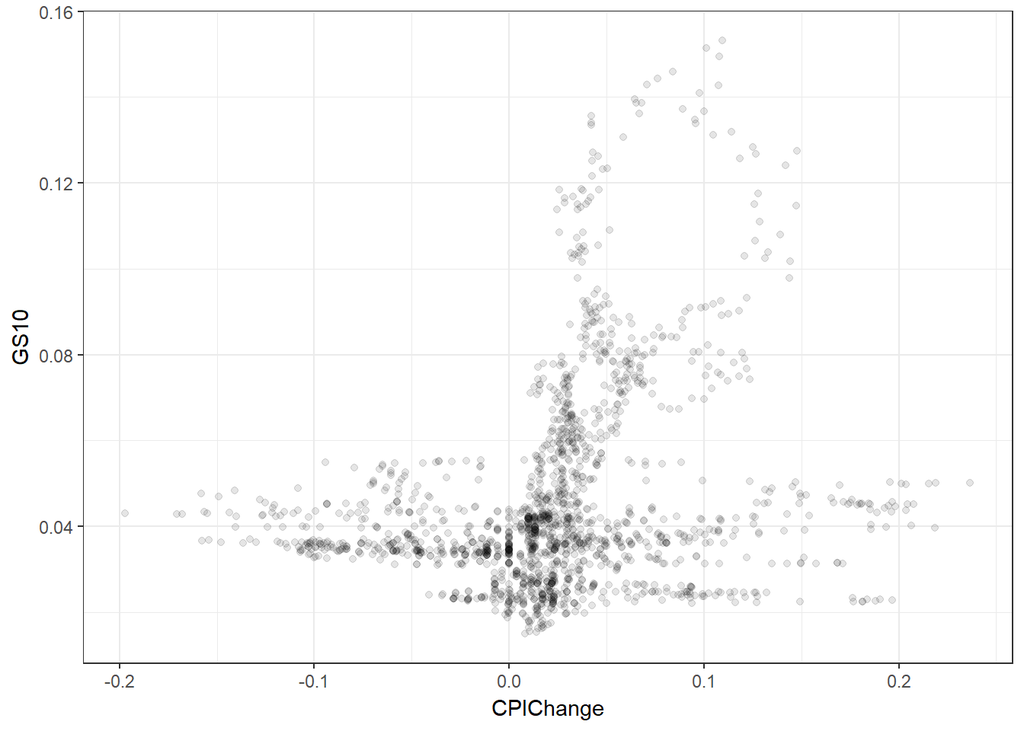

No correlation was visible between Inflation( as CPIChange) and the GS10 rates. I was expecting to find one because of the Federal Reserve’s use of rate policy to manage the inflation rate. It’s possible that there is a delay between market changes and policy reactions, and that lagging one against the other would reveal correlation.

# Bivariate Analysis

### Talk about some of the relationships you observed in this part of the investigation. How did the feature(s) of interest vary with other features in the dataset?

Forward returns were negatively correlated with CAPE. They did not show correlation to Momentum, Inflation or the GS10 rates. However, their distribution did appear tighter in the 1 year forward returns following rising momentum.

### Did you observe any interesting relationships between the other features (not the main feature(s) of interest)?

Price, Dividend and Earnings were all highly correlated. This was expected as it was visible in the time series plots that they have varied together over the duration of the dataset.

CAPE and GS10 had a weak negative correlation. This could be the affect of investors being willing to pay a higher price for returns during low interest rate periods, and vice versa.

### What was the strongest relationship you found?

The strongest relationship was between CAPE and forward returns, with the correlation increasing over the longer periods tested.

# Multivariate Plots Section

### Growth and CAPE vs Foward Returns

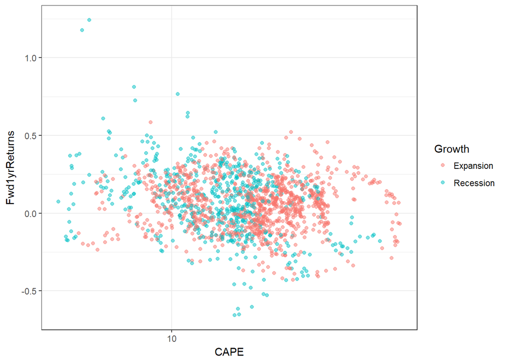

It’s difficult to see in this plot, but it does look like there is a stronger trend between CAPE and forward 1 year returns during periods of recession.

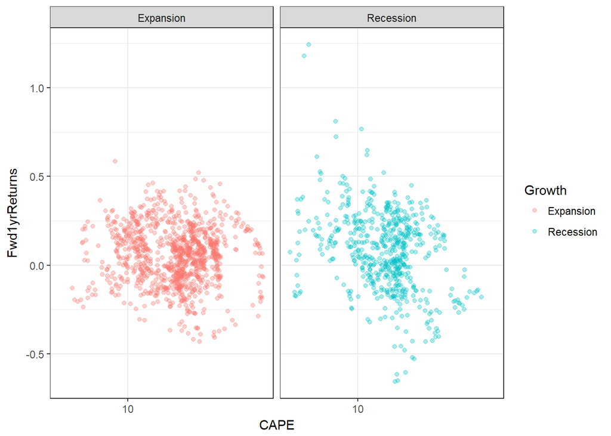

Using `facet_wrap` to separate the conditions makes the difference easier to see. Periods of recession in the stock market exhibit a stronger negative correlation between CAPE and price than during expansion.

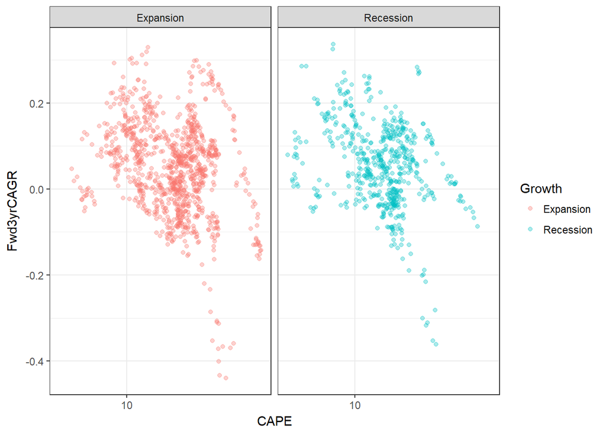

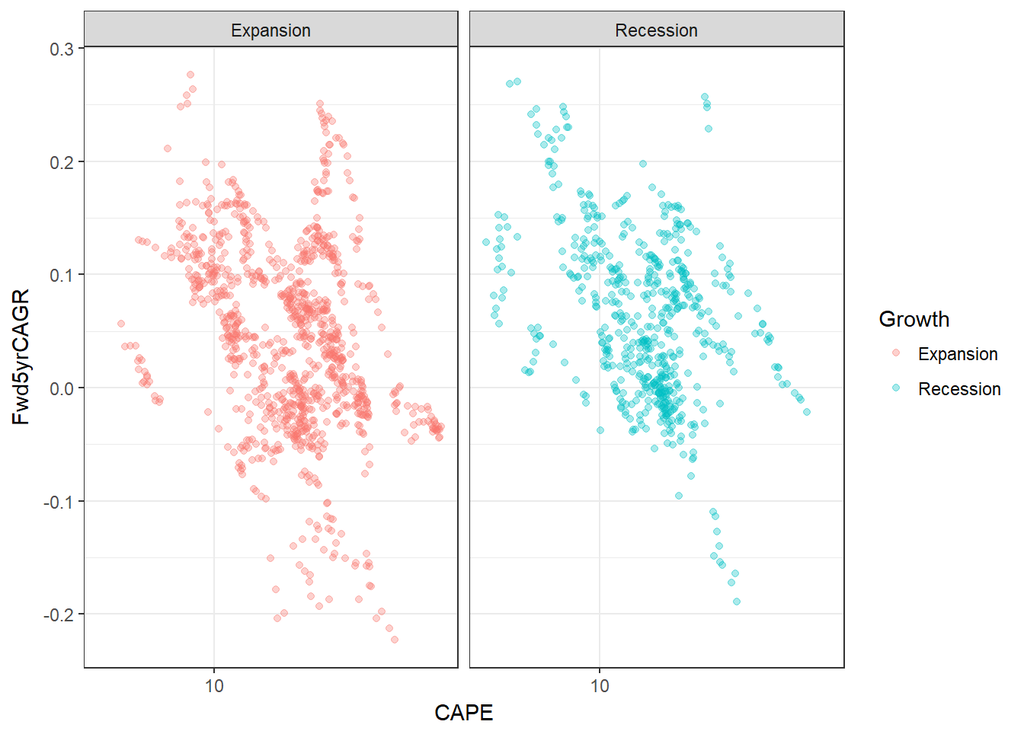

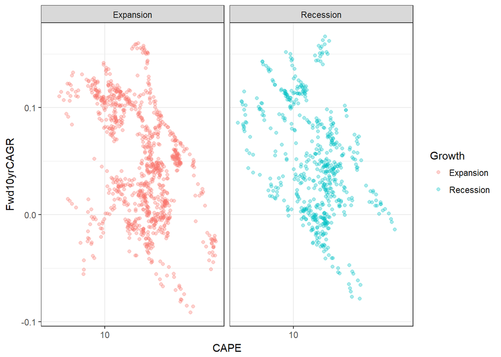

The feature combination doesn’t appear to have the same benefit over longer time periods.

### CAPE and Inflation to Returns

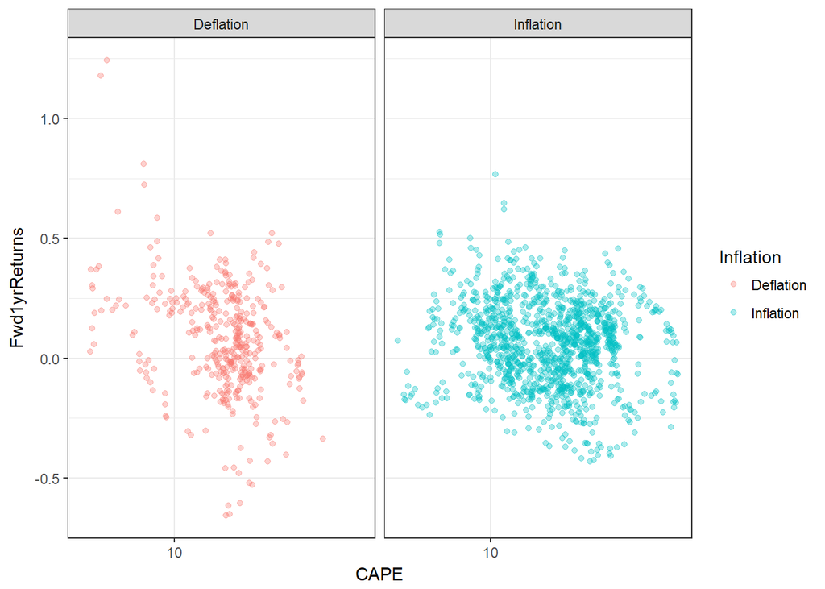

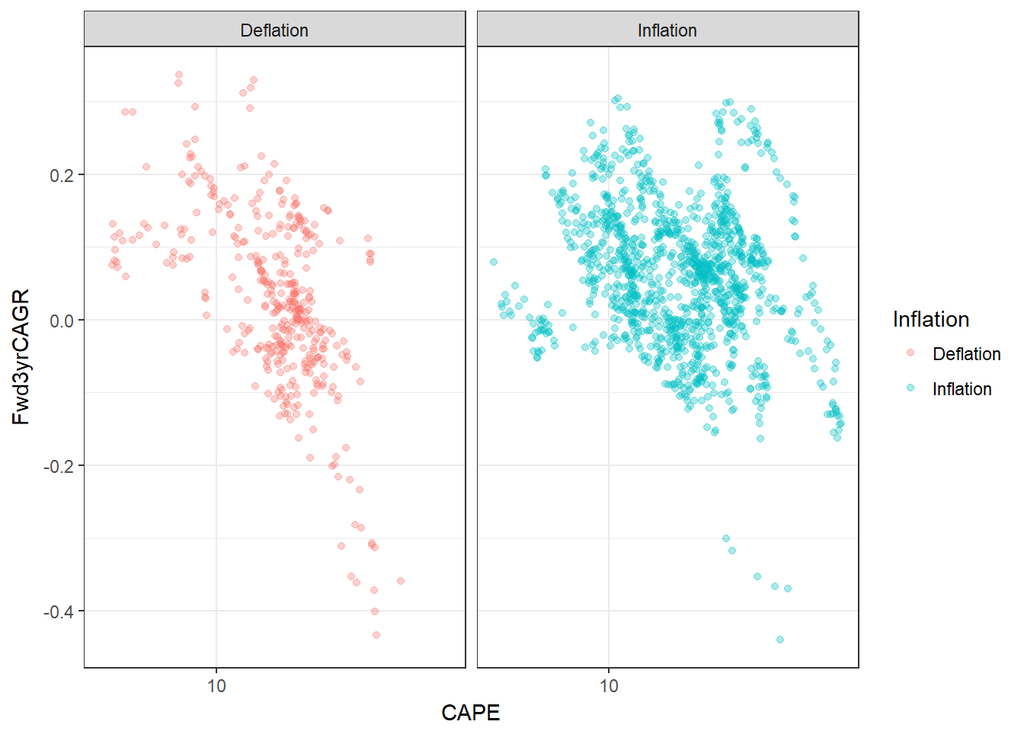

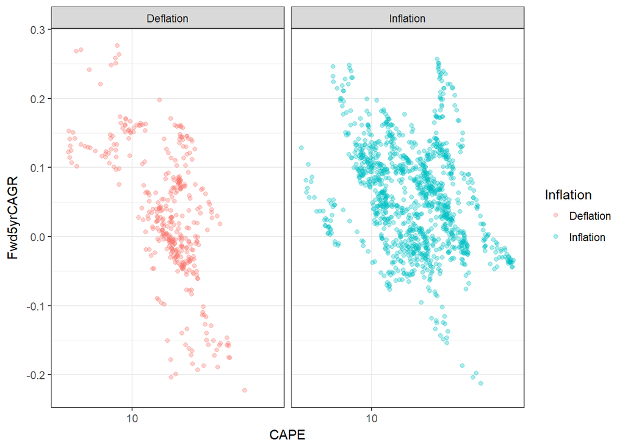

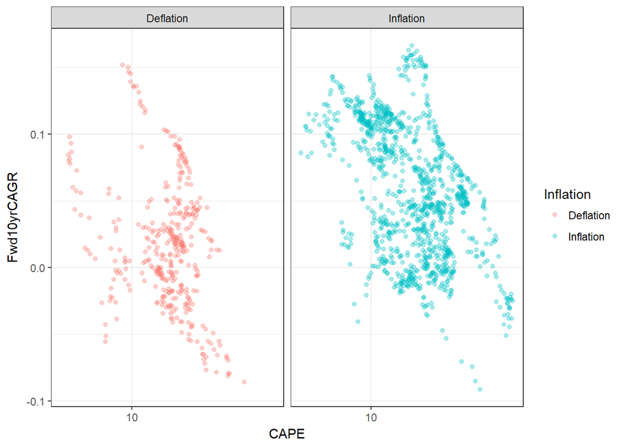

Inflation and Deflation also appear to complement CAPE’s correlation to returns.

The numeric measures of Inflation and Growth did not show correlation during bivariate analysis, suggesting that they should work well together to enhance the power of CAPE.

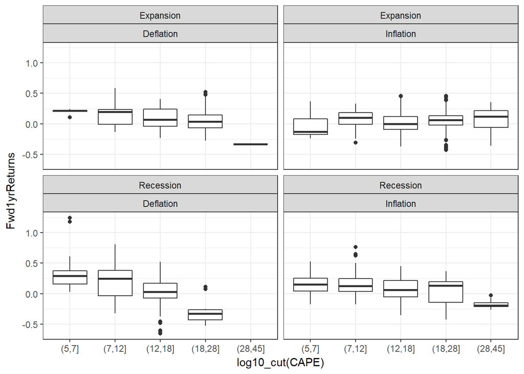

CAPE looks strongest in predicting forward 1 year returns during deflationary recession years.

### The search for yield

The inverse of CAPE can be interpreted as a yield similar to interest rates. Are investors willing to pay more for earnings when interest rates are low?

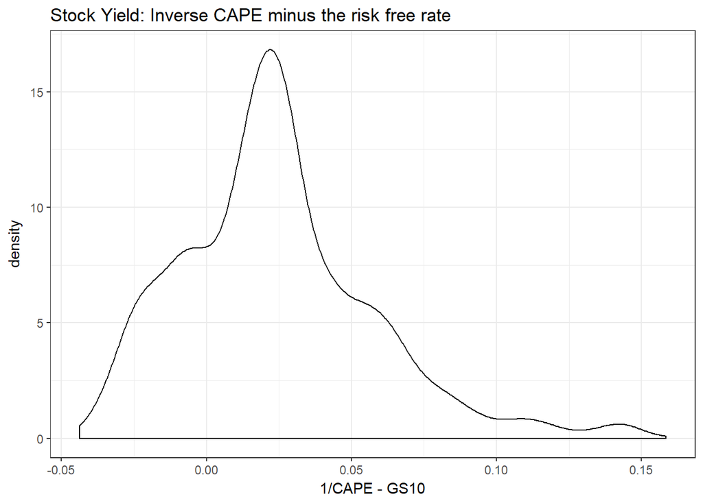

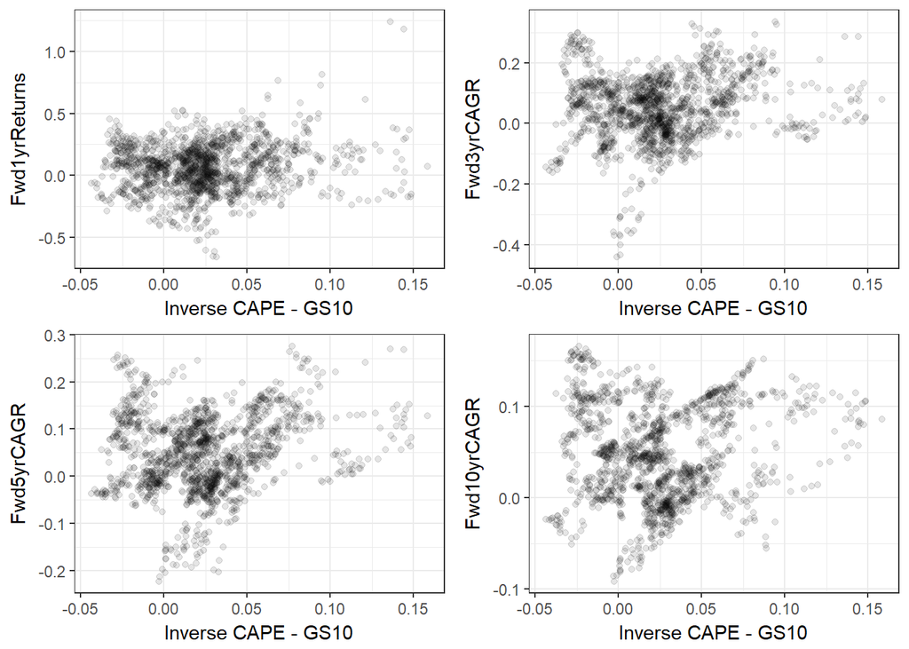

There does appear to be a positive correlation between the excess yield of stocks and forward returns.

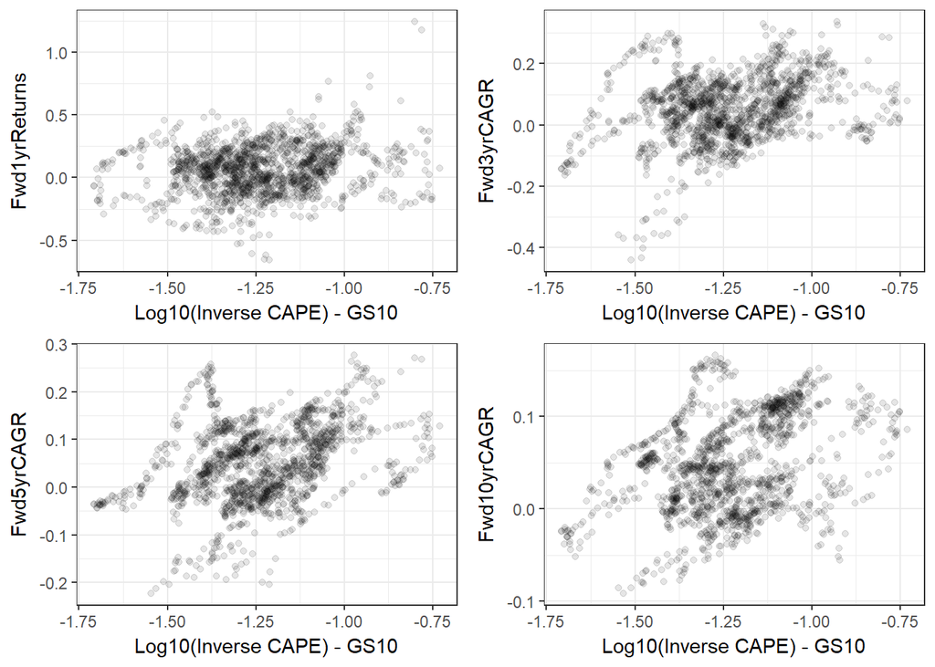

Using the log10 inverse of CAPE makes the relationship look even stronger. The Pearson R correlations between the new value and forward returns are .18, .28, .34 and .35, indicating that this combination does not provide any benefit. These values are slightly lower than using CAPE alone.

### Prediciting the future

I will use `lm` to fit a linear model to predict future returns.

```
##
## Calls:
## Model 1: lm(formula = Fwd1yrReturns ~ log10(CAPE) + Growth + Inflation +
##     GS10, data = cape)
## Model 2: lm(formula = Fwd3yrCAGR ~ log10(CAPE) + Growth + Inflation +
##     GS10, data = cape)
## Model 3: lm(formula = Fwd5yrCAGR ~ log10(CAPE) + Growth + Inflation +
##     GS10, data = cape)
## Model 4: lm(formula = Fwd10yrCAGR ~ log10(CAPE) + Growth + Inflation +
##     GS10, data = cape)
##
## ===========================================================================================
##                                      Model 1       Model 2       Model 3       Model 4
##                                  -------------- ------------- ------------- -------------
##                                   Fwd1yrReturns   Fwd3yrCAGR    Fwd5yrCAGR   Fwd10yrCAGR
## -------------------------------------------------------------------------------------------
##   (Intercept)                         0.290***       0.233***      0.198***      0.138***
##                                      (0.038)        (0.020)       (0.015)       (0.009)
##   log10(CAPE)                        -0.193***      -0.183***     -0.161***     -0.118***
##                                      (0.028)        (0.015)       (0.011)       (0.006)
##   Growth: Recession/Expansion         0.001         -0.008         0.007        -0.006*
##                                      (0.010)        (0.005)       (0.004)       (0.002)
##   Inflation: Inflation/Deflation     -0.012          0.034***      0.024***      0.034***
##                                      (0.011)        (0.006)       (0.004)       (0.003)
##   GS10                                0.238          0.251*        0.465***      0.522***
##                                      (0.206)        (0.110)       (0.082)       (0.048)
## -------------------------------------------------------------------------------------------
##   R-squared                           0.036          0.117         0.182         0.352
##   adj. R-squared                      0.034          0.115         0.180         0.351
##   sigma                               0.184          0.097         0.072         0.041
##   F                                  15.355         53.491        88.231       207.330
##   p                                   0.000          0.000         0.000         0.000
##   Log-likelihood                    452.680       1474.437      1924.220      2699.048
##   Deviance                           55.129         15.177         8.257         2.622
##   AIC                              -893.360      -2936.874     -3836.440     -5386.096
##   BIC                              -860.957      -2904.558     -3804.215     -5354.101
##   N                                1637           1613          1589          1529
## ===========================================================================================
```

The strongest predictions were for 10 year forward returns, but with only 35% of the variance in returns being explained by the model.

A classification model can also be used to predict the Outlook variable. I used `rpart` to create a tree-based model to predict if the next year would be bullish or bearish.

```
##          pred
##           Bearish Bullish
##   Bearish     372     272
##   Bullish     114     999
```

The model was 78% accurate in labeling the dataset. One way of measuring the power of a classification model is to compare it to a majority classifier, which would have labelled all of the data as bullish with 63% accuracy.

# Multivariate Analysis

### Talk about some of the relationships you observed in this part of the investigation. Were there features that strengthened each other in terms of looking at your feature(s) of interest?

The Growth and Inflation features both strengthened the correlation between CAPE and 1 year forward returns. CAPE appears to have the strongest correlation to forward returns after periods of recession and deflation. One possible explanation is that periods of expanding growth and inflation push all prices up, without discrimination to the fundamental value of the market. In the reverse situation, a benefit of this relationship is that CAPE can be used to help identify good opportunities after stock and consumer prices have been falling.

### Were there any interesting or surprising interactions between features?

### OPTIONAL: Did you create any models with your dataset? Discuss the strengths and limitations of your model.

Linear models were used to predict future returns. The models showed that returns are easier to predict over longer time horizons, but even the 10 year model was only able to predict 35% of the variation in returns.

A classification model was able to predict the 1 year outlook with 78% accuracy. This showed some strength over the majority classier.

To settle curiosity, the models are 71% confident that the next year will be bullish, but are only expecting a 1% return over the next 10 years (as of May 2018).

One caveat to keep in mind is that I did not split the data into training and test sets to control for over-fitting. These models were purely for exploring relationships in the data.

# Final Plots and Summary

### Plot One

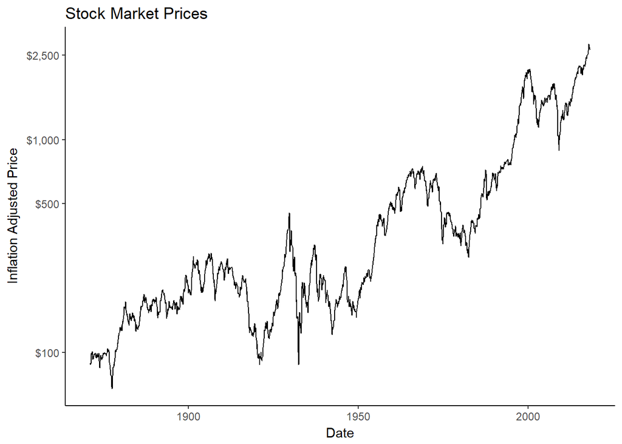

### Description One

This plot shows the log adjusted change in stock prices since 1871. Stocks have been a good investment, but the ride has been anything but smooth.

### Plot Two

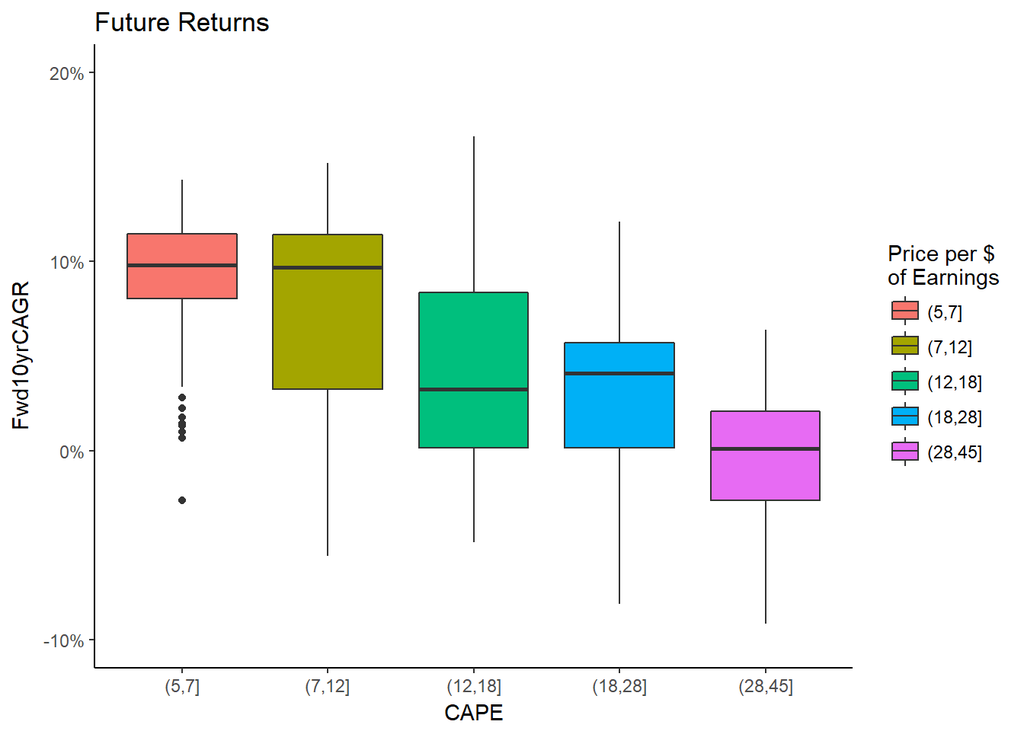

### Description Two

Market valuations have power in predicting future returns. The average 10 year returns for the stock market are higher and with less variance starting from low CAPE readings. Coincidentally, the CAPE ratio is currently at 31 as of 2018-05-01. Current valuations suggest that the 10 year outlook for stocks is grim, which runs contrary to public opinion.

### Plot Three

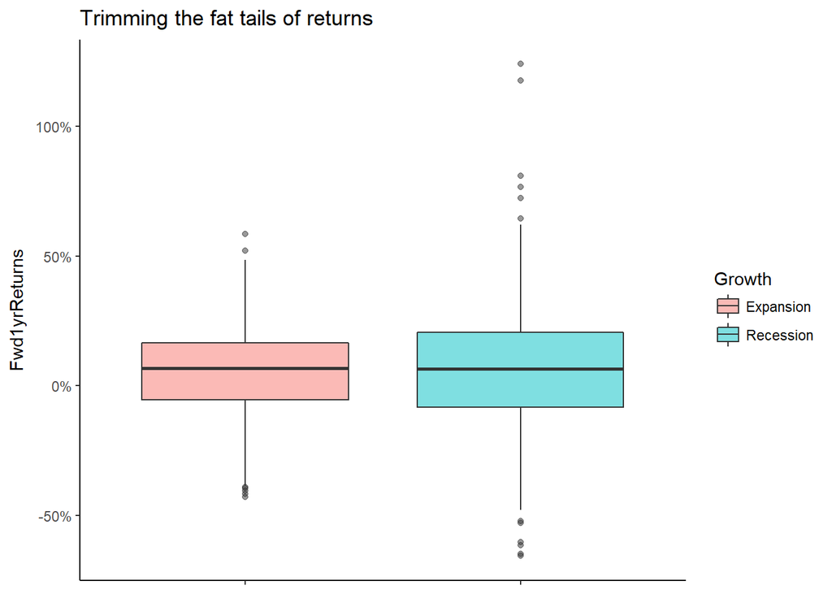

### Description Three

Periods of expansion have less variance in returns than those of recession. This is a subtle, but important effect. Most investors have a hard time dealing with volatility. They can benefit from an indicator letting them know when to step aside or increase diversification (i.e. tilt portfolio allocations to bonds).

# Reflection

This project gave me the opportunity to explore an interesting dataset covering over 100 years of stock market data. Some wrangling was required to prepare the data and create additional features of interest. I began by exploring all of the variables, creating a few interesting ones along the say. Then I analyzed the interactions between the features and finally created a few models for predicting stock market action.

Several variables were found to be correlated to future returns. These included the CAPE valuation ratio, interests rates and inflation. However, none of the correlations were very strong. This made building an accurate model for predicting the future returns difficult, with the strongest model only predicting 35% of the variance of returns. On the other hand, predicting whether the next year was bullish or bearish proved easier. A classification tree model was able to predict this feature with 78% accuracy.

This analysis could be enhanced by introducing additional asset classes to the dataset and building a model that created actionable predictions. For example, a model could be created to predict which asset would have the best performance and used to guide portfolio allocation.

[^1]: [StockCharts Irrational Exuberance Review](http://stockcharts.com/school/doku.php?id=chart_school:overview:%20irrational_exuberanc)
[^2]: [Robert Shiller’s Irrational Exuberance Data](http://www.econ.yale.edu/~shiller/data.htm)
[^3]: [Returns to Buying Winners and Selling Losers](https://www.jstor.org/stable/2328882)
[^4]: [A brief history of dividend tax rates](http://www.dividend.com/taxes/a-brief-history-of-dividend-tax-rates/)